# The Effect of Discounts on Retail Sales

A Machine Learning Analysis of Discount Strategy and Revenue Performance

Group 1 — Jake Evans, Mickyas Shawel, Aldo Naranjo, Luis Berumen, Tim Arana

IBM 6540 | Applied Machine Learning for Marketing | Cal Poly Pomona

August 12, 2026

# Introduction

## Problem Definition

Retailers face a persistent tension between offering discounts to drive volume and protecting per-transaction revenue. Key questions include:

- Do discounts actually increase units sold?
- At what point do discounts reduce net revenue?
- Which product categories and seasons respond differently to promotional pricing?
- Can a machine learning model reliably predict revenue outcomes from discount strategy?

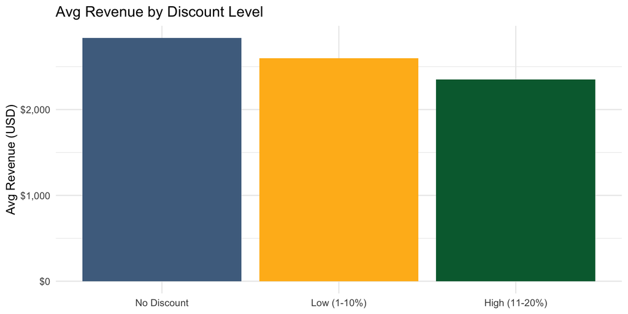

## Research Objectives

**Five research objectives guide our analysis:**

[output not shown]

**Our overarching analytics objective:**

> Build supervised machine learning models that predict retail sales performance from discount strategy, marketing spend, product category, and seasonal features using 30,000 transaction-level records from 2022 to 2024.

## Why This Research Matters

- **For retailers:** Discounting is one of the most common promotional tools, but the margin impact is often unclear. Understanding the revenue consequences of different discount levels by category and season allows more precise promotional planning.
- **For marketing analysts:** Machine learning models that predict whether a transaction will generate above-median revenue give analysts a decision tool that goes beyond aggregate reporting.
- **For the field:** Most existing research treats discounts in isolation. This project examines discount effects alongside marketing spend, seasonality, holiday effects, and product category simultaneously.

# Population & Sample

## Population and Sample

**Population of interest:** Retail transactions across product categories in a multi-store, multi-region retail environment.

**Sample:** 30,000 transaction-level records from a Kaggle synthetic retail dataset designed to reflect realistic retail patterns (2022–2024).

**Note**

The group is using synthetic data for this analysis. Real transaction data was not available for this project. Findings should be interpreted in the context of the synthetic data generating process.

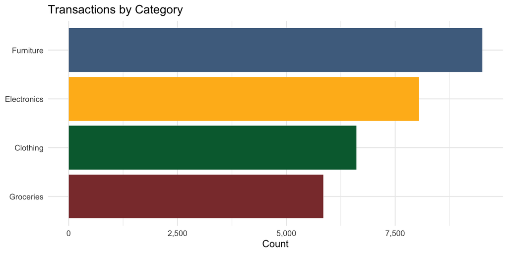

## Sample Characteristics

Key Dataset Summary Statistics

| Metric | Value |
| --- | --- |
| Total Transactions | 30,000 |
| Date Range | 2022-01-01 to 2024-01-01 |
| Avg Revenue | $2,749.51 |
| Median Revenue | $1,902.42 |
| Avg Discount % | 3% |
| Avg Units Sold | 6.2 |
| Avg Marketing Spend | $49.94 |
| Holiday Transactions % | 0.5% |